# EDA : Propiedades Airbnb Madrid

## Análisis exploratorio de los datos de las propiedades Airbnb en Madrid en 2019

### Beatriz Cáradaba Rico

#### 30/10/2020

Se va a realizar un análisis exploratprio de los datos de las propiedades Airbnb que estuvieron en algún momento activas durante el año 2019 en Madrid. El análisis va a seguir la siguiente estructura:

- Importación y transformación de datos:
  - Importar datos.
  - Diccionario de datos.
  - Data Cleaning:
    - Duplicados.
    - Missing Values.
  - Transformación tipo de datos.
- Análisis aislado de variables.
  - Variables numéricas:
    - Medidas estadísticas.
    - Outliers.
    - Histogramas.
  - Variables categóricas.
- Análisis bibariante:
  - Diagramas de dispersión entre variables numéricas.
  - Matriz de Correlaciones.
- Referencias

# Importación y transformación de datos

#### Se importan las diferentes librerías que vamos a utilizar en el EDA

```python
import numpy as np # linear algebra
import pandas as pd # data processing, CSV file I/O (e.g. pd.read_csv)
import seaborn as sns
import matplotlib.pyplot as plt
from pandas_profiling import ProfileReport
from datetime import datetime
```

#### Se importa el dataset que se va a anilizar en este EDA

```python
airbnb = pd.read_csv('../../README.md/data/01_raw/listings.csv')
```

```python
airbnb.head() # visualizamos el Dataset para ver que se ha importado correctamente
```

|  | id | name | host_id | host_name | neighbourhood_group | neighbourhood | latitude | longitude | room_type | price | minimum_nights | number_of_reviews | last_review | reviews_per_month | calculated_host_listings_count | availability_365 |
| --- | --- | --- | --- | --- | --- | --- | --- | --- | --- | --- | --- | --- | --- | --- | --- | --- |
| 0 | 6369 | Rooftop terrace room with ensuite bathroom, Airc. | 13660 | Simon | Chamartín | Hispanoamérica | 40.45628 | -3.67763 | Private room | 70 | 1 | 65 | 2019-09-04 | 0.56 | 1 | 53 |
| 1 | 21853 | Bright and airy room | 83531 | Abdel | Latina | Cármenes | 40.40341 | -3.74084 | Private room | 17 | 4 | 33 | 2018-07-15 | 0.55 | 2 | 48 |
| 2 | 24805 | Gran Via Studio Madrid | 101471 | Iraido | Centro | Universidad | 40.42202 | -3.70395 | Entire home/apt | 80 | 5 | 2 | 2017-07-03 | 0.03 | 1 | 354 |
| 3 | 24836 | Select the Madrid more "cool". | 101653 | Tenty | Centro | Justicia | 40.41995 | -3.69764 | Entire home/apt | 115 | 3 | 64 | 2019-07-07 | 0.63 | 1 | 301 |
| 4 | 26825 | Single Room whith private Bathroom | 114340 | Agustina | Arganzuela | Legazpi | 40.38985 | -3.69011 | Private room | 25 | 2 | 136 | 2019-07-10 | 1.19 | 1 | 337 |

```python
airbnb.shape # Analizamos la fomra de nuestro data Set. Tiene 20837 filas(prpiedades Airbnb) y 16 columnas (variables)
```

```
(20837, 16)
```

Como se ve en el dat frame importado para cada propiedad Airbnb se nombran unas características definidas a continuación:

### Diccionario de datos:

- 'id' : Código único de identificación de cada propiedad.
- 'name': Nombre de la propiedad
- 'host_id': Código unico de identificacion del dueño de cada propiedad. Código de proietario
- 'host_name': Nombre del propietario
- 'neighbourhood_group': Distrito
- 'neighbourhood': Barrio
- 'latitude': coordenadas de la latitud de la propiedad
- 'longitude': coordenadas de la longitud de la propiedad
- 'room_type': tipo de alojamiento
- 'price': precio por noche del alojamiento
- 'minimum_nights': estancia mínima en noches que admite el alojamiento
- 'number_of_reviews': Número de opiniones del alojamiento
- 'last_review': Última opinión del alojamiento
- 'reviews_per_month': opininiones medias por mes del alojamiento desde que comenzó su actividad
- 'calculated_host_listings_count':
- 'availability_365': días que el alojamiento ha estado libre de los últimos 365 desde la extracción de los datos

### Proceso de Data Cleaning.

**Duplicados:**

Es importante conocer si existen filas duplicadas en el data frame

```python
airbnb.duplicated().sum() # la función duplicated nos indica si hay alguna fila duplicada en el dataset
```

```
0
```

En este caso no hay ningún valor duplicado

**Missing values.**

Analizamos la cantidad de valores no informados para cada columna

```python
airbnb.isnull().sum() # utilizamos la funcion isnull para localizar los na, y la función sum para que nos sume los na por column
```

```
id                                   0
name                                 5
host_id                              0
host_name                           15
neighbourhood_group                  0
neighbourhood                        0
latitude                             0
longitude                            0
room_type                            0
price                                0
minimum_nights                       0
number_of_reviews                    0
last_review                       4654
reviews_per_month                 4654
calculated_host_listings_count       0
availability_365                     0
dtype: int64
```

Hay cuatro varibles que contienen valores nos informados, es importante tenerlo en cuenta a la hora de analizarlas. Cambiamos los valores no informados por 0:

```python
airbnb = airbnb.fillna(0) # cambiamos todos los na del df por 0
airbnb.isnull().sum() # comporbamos que ya no hay NA en el df
```

```
id                                0
name                              0
host_id                           0
host_name                         0
neighbourhood_group               0
neighbourhood                     0
latitude                          0
longitude                         0
room_type                         0
price                             0
minimum_nights                    0
number_of_reviews                 0
last_review                       0
reviews_per_month                 0
calculated_host_listings_count    0
availability_365                  0
dtype: int64
```

Comprobamos que ya no existen campos "vacíos"

Conocemos el nombre de las columnas y el tipo de dato almacenado en cada variable que es importante para realizar cálculos posteriores

```python
airbnb.info()
```

```
<class 'pandas.core.frame.DataFrame'>
RangeIndex: 20837 entries, 0 to 20836
Data columns (total 16 columns):
 #   Column                          Non-Null Count  Dtype
---  ------                          --------------  -----
 0   id                              20837 non-null  int64
 1   name                            20837 non-null  object
 2   host_id                         20837 non-null  int64
 3   host_name                       20837 non-null  object
 4   neighbourhood_group             20837 non-null  object
 5   neighbourhood                   20837 non-null  object
 6   latitude                        20837 non-null  float64
 7   longitude                       20837 non-null  float64
 8   room_type                       20837 non-null  object
 9   price                           20837 non-null  int64
 10  minimum_nights                  20837 non-null  int64
 11  number_of_reviews               20837 non-null  int64
 12  last_review                     20837 non-null  object
 13  reviews_per_month               20837 non-null  float64
 14  calculated_host_listings_count  20837 non-null  int64
 15  availability_365                20837 non-null  int64
dtypes: float64(3), int64(7), object(6)
memory usage: 2.1+ MB
```

Se observa que en un primer momento hay 10 variables numéricas y 6 de tipo objeto. Sin embargo, hay que hacer algunas transformaciones en algunas columnas ya que aunque sean "números" son variables categóricas. Es el caso de "id" y "host_id". Cambiamos también tipo fecha de last_review

**Transformación de tipos de datos**

```python
airbnb[["id", "host_id"]] = airbnb[["id", "host_id"]].astype(object)# cambiamos las variables a tipo objeto ya que son categorí
airbnb["last_review"] = pd.to_datetime(airbnb["last_review"],format = '%Y/%m/%d')
```

Comprobamos que el cambio es efetivo:

```python
airbnb.info()
```

```
<class 'pandas.core.frame.DataFrame'>
RangeIndex: 20837 entries, 0 to 20836
Data columns (total 16 columns):
 #   Column                          Non-Null Count  Dtype
---  ------                          --------------  -----
 0   id                              20837 non-null  object
 1   name                            20837 non-null  object
 2   host_id                         20837 non-null  object
 3   host_name                       20837 non-null  object
 4   neighbourhood_group             20837 non-null  object
 5   neighbourhood                   20837 non-null  object
 6   latitude                        20837 non-null  float64
 7   longitude                       20837 non-null  float64
 8   room_type                       20837 non-null  object
 9   price                           20837 non-null  int64
 10  minimum_nights                  20837 non-null  int64
 11  number_of_reviews               20837 non-null  int64
 12  last_review                     20837 non-null  datetime64[ns]
 13  reviews_per_month               20837 non-null  float64
 14  calculated_host_listings_count  20837 non-null  int64
 15  availability_365                20837 non-null  int64
dtypes: datetime64[ns](1), float64(3), int64(5), object(7)
memory usage: 2.0+ MB
```

# Análisis aislado de variables:

## Análisis de variables numéricas:

**Medidas estadísticas:**

```python
airbnb.describe() # la funcion descibre nos devuelve diferentes medidas de cada variable numérica.
```

|  | latitude | longitude | price | minimum_nights | number_of_reviews | reviews_per_month | calculated_host_listings_count | availability_365 |
| --- | --- | --- | --- | --- | --- | --- | --- | --- |
| count | 20837.000000 | 20837.000000 | 20837.000000 | 20837.000000 | 20837.000000 | 20837.000000 | 20837.000000 | 20837.000000 |
| mean | 40.420548 | -3.694500 | 134.065364 | 4.373614 | 35.163891 | 1.521432 | 12.188559 | 155.097567 |
| std | 0.021881 | 0.027793 | 381.207575 | 20.428777 | 61.863053 | 1.916618 | 32.156130 | 133.746263 |
| min | 40.319480 | -3.890940 | 8.000000 | 1.000000 | 0.000000 | 0.000000 | 1.000000 | 0.000000 |
| 25% | 40.409550 | -3.707490 | 40.000000 | 1.000000 | 1.000000 | 0.070000 | 1.000000 | 17.000000 |
| 50% | 40.418900 | -3.701180 | 65.000000 | 2.000000 | 8.000000 | 0.750000 | 2.000000 | 123.000000 |
| 75% | 40.429020 | -3.689110 | 100.000000 | 3.000000 | 42.000000 | 2.360000 | 7.000000 | 300.000000 |
| max | 40.573990 | -3.527660 | 9999.000000 | 1125.000000 | 594.000000 | 34.230000 | 231.000000 | 365.000000 |

Esta tabla nos indica la cuenta de los valores de cada variable, la media, la disviación típica, los cuartiles y los máximos y mínímos de cada variable. Por ejemplo, conocemos que el precio medio de una noche de airbnb en Madrid es 134€

**Outliers - BOX-PLOTS:**

Visualizamos los utliers de cada variable mediante boxplots

```python
# primero credo df para cada una de las columnas que quiero representrar en los boxplot. Son totdas las numéricas
airbnb_latitude = airbnb['latitude']
airbnb_longitude = airbnb['longitude']
airbnb_price = airbnb['price']
airbnb_minimum_nights = airbnb['minimum_nights']
airbnb_number_of_reviews = airbnb['number_of_reviews']
airbnb_reviews_per_month = airbnb['reviews_per_month']
airbnb_calculated_host_listings_count = airbnb['calculated_host_listings_count']
airbnb_availability_365 = airbnb['availability_365']
```

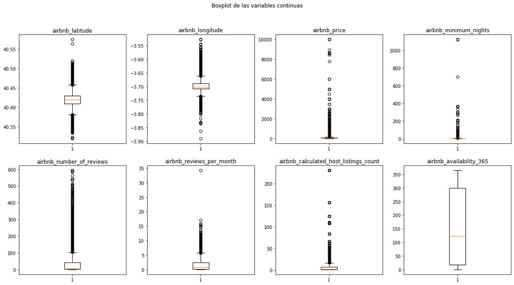

```python
# Para hacer graficos primero diseño la salida. en este caso repartop los graficos en dos filas de cuatro columnas, 8 boxplots
fig, ax = plt.subplots(nrows = 2, ncols =4,  figsize=(20,10))
fig.suptitle('Boxplot de las variables continuas')
# Indico en que parte de la figura quiero colocar cada box plot: ax[0,0]. el tipo de gráfico boxplot y (los datos)
ax[0,0].boxplot(airbnb_latitude)
ax[0,0].set_title('airbnb_latitude') # para poner el tirulo de cada grafico

ax[0,1].boxplot(airbnb_longitude)
ax[0,1].set_title('airbnb_longitude')

ax[0,2].boxplot(airbnb_price)
ax[0,2].set_title('airbnb_price')

ax[0,3].boxplot(airbnb_minimum_nights)
ax[0,3].set_title('airbnb_minimum_nights')

ax[1,0].boxplot(airbnb_number_of_reviews)
ax[1,0].set_title('airbnb_number_of_reviews')

ax[1,1].boxplot(airbnb_reviews_per_month)
ax[1,1].set_title('airbnb_reviews_per_month')

ax[1,2].boxplot(airbnb_calculated_host_listings_count)
ax[1,2].set_title('airbnb_calculated_host_listings_count')

ax[1,3].boxplot(airbnb_availability_365)
ax[1,3].set_title('airbnb_availability_365')
```

De los box-plot podemos conocer la distribución de los datos en las variables numéricas. Obseravamos que en algunas de ellas la mayoría de los valores se encuntran en torno a la mediana, como 'calculated_host_listings_count'. Sin embargo otras variables tienen mucha dispersión como 'airbnb_availability_365'. Los puntos que se quedan más allá de los bigotes son los outliers.

**Distribución de los datos**

Analizamos la distribución de los datos de las variables numéricas

```python
# Creamos un df que contengan todas las variables de tipo numérico
airbnb_num = airbnb.select_dtypes(include = ['float64', 'int64'])
airbnb_num.head()
```

|  | latitude | longitude | price | minimum_nights | number_of_reviews | reviews_per_month | calculated_host_listings_count | availability_365 |
| --- | --- | --- | --- | --- | --- | --- | --- | --- |
| 0 | 40.45628 | -3.67763 | 70 | 1 | 65 | 0.56 | 1 | 53 |
| 1 | 40.40341 | -3.74084 | 17 | 4 | 33 | 0.55 | 2 | 48 |
| 2 | 40.42202 | -3.70395 | 80 | 5 | 2 | 0.03 | 1 | 354 |
| 3 | 40.41995 | -3.69764 | 115 | 3 | 64 | 0.63 | 1 | 301 |
| 4 | 40.38985 | -3.69011 | 25 | 2 | 136 | 1.19 | 1 | 337 |

```
array([[<matplotlib.axes._subplots.AxesSubplot object at 0x0D4A63B0>,
      dtype=object)
```

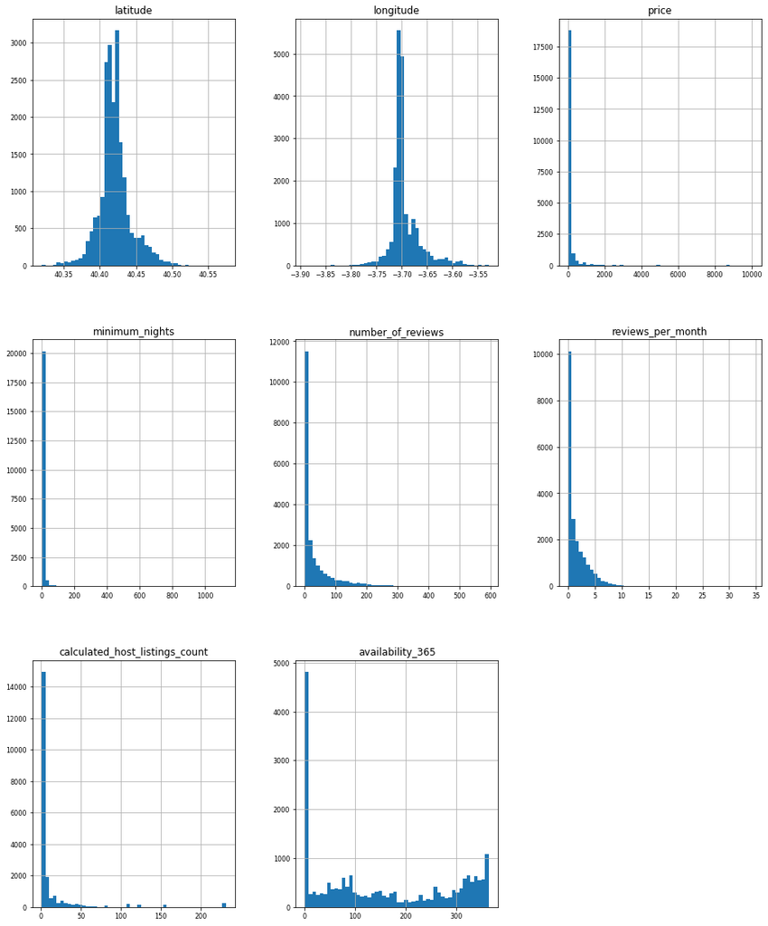

```python
# creamos los histogramas de estas variables
airbnb_num.hist(figsize=(16, 20), bins=50, xlabelsize=8, ylabelsize=8)
```

Se puede oobservar en estos gráficos como las variables pueden tener diferentes distribuciones. En algunas variables la mayoría de las observaciones se concentran en la parte izquierda de la muestra, esto nos puuede indicar que los valores extremos máximos son casos atípicos.

## Análisis variables categóricas:

Para conocer la distribucion de los datos de las variables categóricas podemos elaborar tablas y gráficos de fecuencias. Pero antes hay que conoccer cuantas valores toma en el dataset cada variable categórica. Ya que si una variable categórica cuenta con muchas opciones no podremos realizar una representacion gráfica.

Según el analisis desde punto de vista de negocio, no considero relevante hacer un analisis del nombre de la propiedad y del nombre del propietario ya que puede repertirse en observaciones totalmente independientes.

```python
# Creamos un df que contengan todas las variables de tipo objeto
airbnb_cat = airbnb.select_dtypes(include = ['object'])
airbnb_cat.head()
```

|  | id | name | host_id | host_name | neighbourhood_group | neighbourhood | room_type |
| --- | --- | --- | --- | --- | --- | --- | --- |
| 0 | 6369 | Rooftop terrace room with ensuite bathroom, Airc. | 13660 | Simon | Chamartín | Hispanoamérica | Private room |
| 1 | 21853 | Bright and airy room | 83531 | Abdel | Latina | Cármenes | Private room |
| 2 | 24805 | Gran Via Studio Madrid | 101471 | Iraido | Centro | Universidad | Entire home/apt |
| 3 | 24836 | Select the Madrid more "cool". | 101653 | Tenty | Centro | Justicia | Entire home/apt |
| 4 | 26825 | Single Room whith private Bathroom | 114340 | Agustina | Arganzuela | Legazpi | Private room |

**id**

```python
# queremos saber cuantas propiedades diferentes hay en el df. Como hemos visto que no hay duplicados sabemos que cada
# propiedad solo está una vez
Propiedades_Airbnb = len(airbnb['id'].unique())
f" Durante el 2019 se ofertaron {Propiedades_Airbnb} propiedades de Airbnb en Madrid"
```

```
' Durante el 2019 se ofertaron 20837 propiedades de Airbnb en Madrid'
```

```python
airbnb_cat.id.duplicated().sum() # miramos si hay duplicados en id
```

```
0
```

No hay ningún id duplicado, por lo que cada fila representa una propiedad

**host_id**

```python
# contamos los valores unicos de propietarios
Propietarios_Airbnb = len(airbnb['host_id'].unique())
f" Durante el 2019 hubo {Propietarios_Airbnb} propietarios de Airbnb en Madrid"
```

```
' Durante el 2019 hubo 11969 propietarios de Airbnb en Madrid'
```

```python
# miramos cuantos propietarios estan repetido, es decir, tienen más de una propiedad asociada
Propietarios_Airbnb_dupli = airbnb_cat.host_id.duplicated().sum()
f" Durante el 2019 hubo {Propietarios_Airbnb_dupli} propietarios con más de una propiedad Airbnb en Madrid"
```

[output not shown]

Analizamos cuantos Airbnb tiene cada propietario:

```python
# Agrupamos para cadapropiertario la cuenta de las propiedades airbnb que tiene
Airbnb_por_Propietario = airbnb.groupby(['host_id']).id.count()
# Creamos el df para poder ordenarlo de mayor número de propiedades a menor.
Airbnb_por_Propietario = pd.DataFrame(Airbnb_por_Propietario)
Airbnb_por_Propietario = Airbnb_por_Propietario.sort_values(['id'], ascending = False)
Airbnb_por_Propietario
```

| host_id | id |
| --- | --- |
| 102947901 | 231 |
| 261942593 | 156 |
| 206349691 | 124 |
| 99018982 | 110 |
| 28038703 | 108 |
| ... | ... |
| 44233425 | 1 |
| 44245412 | 1 |
| 44251053 | 1 |
| 44255158 | 1 |
| 296084664 | 1 |

11969 rows × 1 columns

**Distrito**

Analizamos el número de Airbnb por distrito

```python
# Agrupamos las propiedades por distrito
Airbnb_por_Distritito = airbnb.groupby(['neighbourhood_group']).id.count()
Airbnb_por_Distritito  = pd.DataFrame(Airbnb_por_Distritito)
Airbnb_por_Distritito
```

| neighbourhood_group | id |
| --- | --- |
| Arganzuela | 1121 |
| Barajas | 165 |
| Carabanchel | 678 |
| Centro | 9773 |
| Chamartín | 551 |
| Chamberí | 1331 |
| Ciudad Lineal | 613 |
| Fuencarral - El Pardo | 300 |
| Hortaleza | 332 |
| Latina | 616 |
| Moncloa - Aravaca | 542 |
| Moratalaz | 127 |
| Puente de Vallecas | 591 |
| Retiro | 665 |
| Salamanca | 1375 |
| San Blas - Canillejas | 524 |
| Tetuán | 838 |
| Usera | 361 |
| Vicálvaro | 65 |
| Villa de Vallecas | 103 |
| Villaverde | 166 |

```python
Airbnb_por_Distritito.describe() # analizamos las medidas estadísticas de los distritos
```

|  | id |
| --- | --- |
| count | 21.000000 |
| mean | 992.238095 |
| std | 2046.362380 |
| min | 65.000000 |
| 25% | 300.000000 |
| 50% | 551.000000 |
| 75% | 678.000000 |
| max | 9773.000000 |

Representamos graficamente el número de airbnb por distrito:

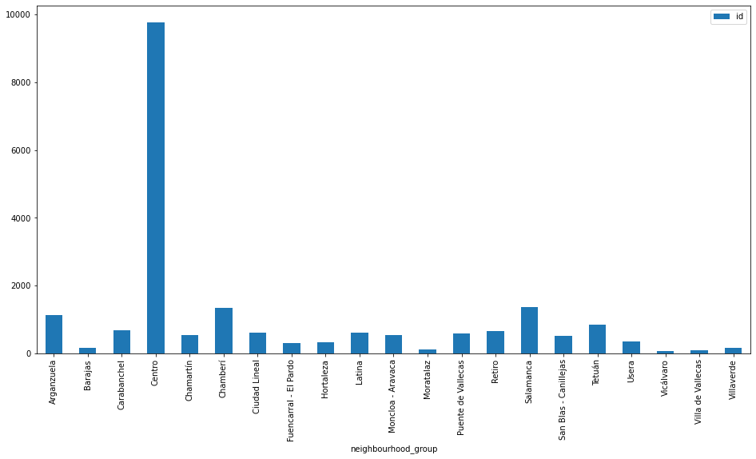

```python
# Como hemos hecho anteriormente, para poder representar graficamente el data frame ambos valores deben ser columns
# primero transformamos el indice en una columna
Airbnb_por_Distritito.reset_index(level=0,inplace=True)
# Representamos la informacion del data frame grafiicamene. en el eje x las diferentes categorías y en el eje Y N_Combates
Airbnb_por_Distritito.plot(x = "neighbourhood_group" , y ="id", kind ="bar",figsize = (16,8))
```

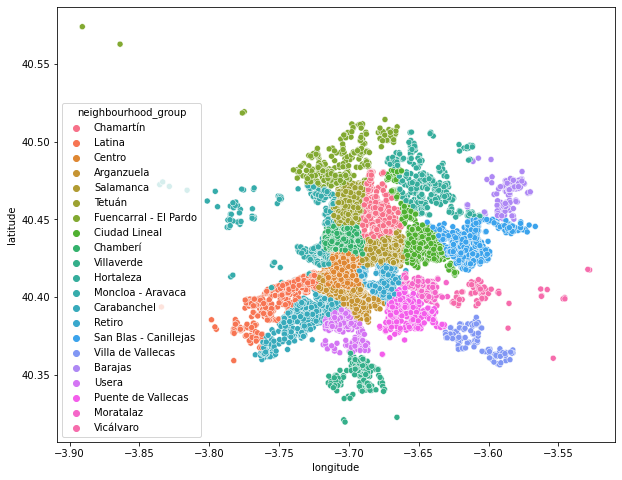

```python
plt.figure(figsize=(10,8))
sns.scatterplot(airbnb.longitude,airbnb.latitude,hue=airbnb.neighbourhood_group)
# situamos os ejes x e y segun las coordenadas de latitud y longitud definidas para Airbnb
plt.ioff()
```

Este mapa representa con un cícula cada Airbnb en Madrid, seprando los distritos en diferentes colores